# Final

2025-12-10

#### Intro

The purpose of this project is to explore whether higher college tuition is associated with higher graduation rates in U.S. institutions. Many people assume that more expensive colleges provide better academic resources, leading to stronger student outcomes, but this is not always demonstrated with data. This project examines that question using a real dataset of U.S. colleges and applies basic exploratory analysis, correlation, and simple linear regression.

###### Hypotheses

H₀: There is no linear relationship between tuition and graduation rate.

H₁: Higher tuition is associated with higher graduation rates

Our goal is to determine whether tuition meaningfully predicts graduation rate, and to assess how strong that relationship is.

#### Data

The dataset used in this analysis is the College.csv dataset, which contains information on 777 U.S. colleges. It includes variables such as out-of-state tuition, enrollment, student demographics, and graduation rates.

The data were imported directly from the provided online resource and cleaned by selecting only the two variables relevant to the research question:

Outstate – Out-of-state tuition (in dollars)

Grad.Rate – Graduation rate (percentage of students graduating)

```r
url <- "https://unsw-risk-and-actuarial-studies.github.io/ACTL3142/M1-Introduction/College.csv"
college <- read.csv(url, stringsAsFactors = FALSE)
```

The final dataset contains 777 observations and 2 variables, with no missing values for the two selected fields. This makes it well-suited for correlation and regression analysis.

#### Description of the Dataset

###### Summary Statistics

Out-of-state tuition (Outstate):

Minimum: $2,340

Median: $9,990

Mean: $10,441

Maximum: $21,700

Tuition varies widely across institutions, with most colleges falling between $7,000 and $13,000, indicating a right-skewed distribution with some high-tuition outliers.

Graduation rate (Grad.Rate):

Minimum: 10%

Median: 65%

Mean: 65.46%

Maximum: 118%

Graduation rates are more tightly distributed, with most colleges between about 50% and 80%. Rates above 100% occur due to the dataset’s definition of extended graduation windows.

###### Visualizations

Histograms show a right-skewed distribution for tuition and a more centered distribution for graduation rates. An initial scatterplot of tuition vs. graduation rate shows a broadly upward trend with considerable spread. Many colleges cluster between 50% and 80% graduation rates, regardless of tuition, but higher-tuition schools tend to lie slightly higher on the vertical axis.

#### Methods

The analysis used three main statistical tools:

1. Summary statistics to understand the basic characteristics of tuition and graduation rates.
2. Pearson correlation to measure the linear association between the two variables.
3. Simple linear regression, with graduation rate as the response variable and tuition as the predictor, to estimate the direction, strength, and significance of the relationship.

A regression line was also added to the scatterplot to visualize the trend.

#### Results

The relationship between tuition and graduation rate was analyzed using correlation and simple linear regression. Tuition ranged from $2,340 to $21,700 (mean = $10,441), while graduation rates ranged from 10% to 118% (mean = 65.46%). The correlation between tuition and graduation rate was r = 0.571, indicating a moderate positive association. A regression analysis confirmed that tuition significantly predicts graduation rate (p < 2e−16). The slope coefficient of 0.002439 suggests that for every additional $1,000 in tuition, the expected graduation rate increases by approximately 2.44 percentage points. The model’s R² value of 0.3264 shows that tuition explains about 32.6% of the variation in graduation rates among colleges. Overall, the results support the hypothesis that higher tuition is associated with higher graduation rates.

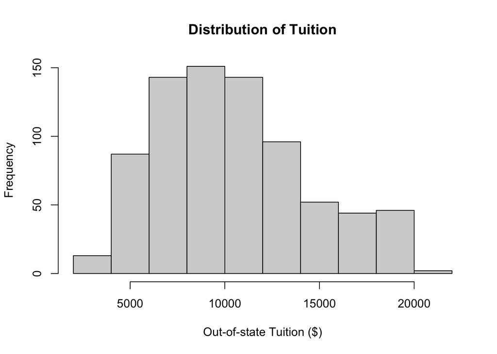

```r
data <- college[, c("Outstate", "Grad.Rate")]
hist(data$Outstate, xlab = "Out-of-state Tuition ($)", main = "Distribution of Tuition")
```

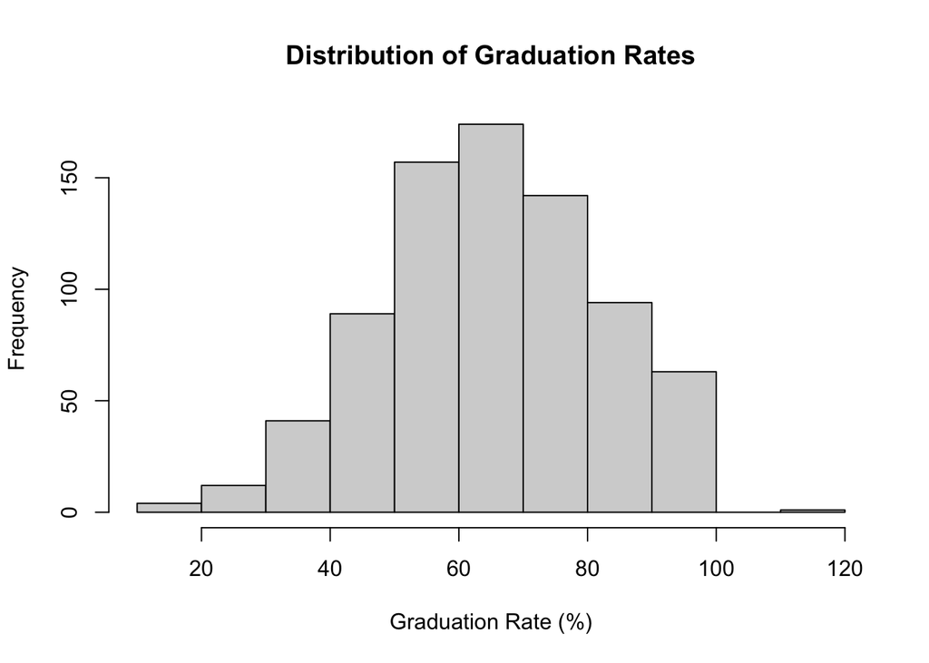

```r
hist(data$Grad.Rate, xlab = "Graduation Rate (%)", main = "Distribution of Graduation Rates")
```

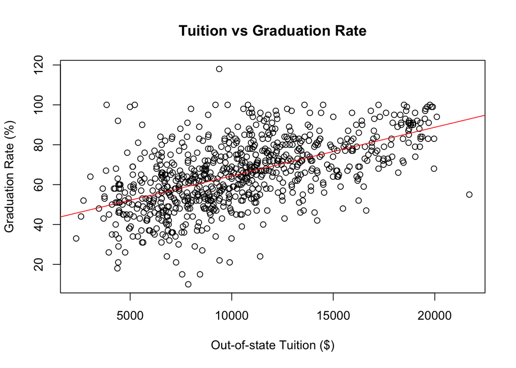

```r
plot(data$Outstate, data$Grad.Rate, xlab = "Out-of-state Tuition ($)", ylab = "Graduation Rate (%)", main = "Tuition vs Graduation Rate")

model <- lm(Grad.Rate ~ Outstate, data = data)
abline(model, col = "red")
```

#### Conclusion

The results support the alternative hypothesis: higher tuition is associated with higher graduation rates. The relationship is statistically significant and moderately strong, with higher-priced colleges generally achieving better graduation outcomes.

However, the regression’s R² value shows that tuition alone does not tell the whole story. Factors such as institutional resources, student preparation, faculty engagement, selectivity, and support services also play major roles in determining student success.

Future work could expand the model by including additional predictors (such as acceptance rates, faculty ratio, or SAT scores) to build a more complete understanding of what drives graduation rates.